# Tidyverse: Lubridate

John Cruz

2023-04-09

## Required Libraries

```r
library(tidyverse)
library(lubridate)
library(httr)
library(jsonlite)
```

## Tidyvserse Packages

Tidyverse contains many packages within it that allows users to work with strings, mutate and rearange dataframes and access data through APIs or websites. We can see a few of these packages listed below.

```r
tidyverse_packages()
```

```
##  [1] "broom"         "cli"           "crayon"        "dbplyr"
##  [5] "dplyr"         "dtplyr"        "forcats"       "ggplot2"
##  [9] "googledrive"   "googlesheets4" "haven"         "hms"
## [13] "httr"          "jsonlite"      "lubridate"     "magrittr"
## [17] "modelr"        "pillar"        "purrr"         "readr"
## [21] "readxl"        "reprex"        "rlang"         "rstudioapi"
## [25] "rvest"         "stringr"       "tibble"        "tidyr"
## [29] "xml2"          "tidyverse"
```

## Import Data

To demonstrate the capabilities of the **lubridate** package within the Tidyverse, I will be using a data set on requested film permits in NYC. As per its documentation “Lubridate provides tools that make it easier to parse and manipulate dates.”

**Description of Data:** The Film Office issues permits to productions filming on location in the City of New York and provides free police assistance, free parking privileges and access to most exterior locations free of charge. Not all filming activity requires a permit. These permits are generally required when asserting the exclusive use of city property, like a sidewalk, a street, or a park.

**Source:** [NYC Filming Permits](https://data.cityofnewyork.us/City-Government/Film-Permits/tg4x-b46p)

```r
import_data <- as.data.frame(fromJSON('https://data.cityofnewyork.us/resource/tg4x-b46p.json', simplifyVector = TRUE))
```

## Brief Glance of the Raw Dataset

```r
knitr::kable(head(import_data, 1))
```

| eventid | eventtype | startdatetime | enddatetime | enteredon | eventagency | parkingheld | borough | communityboard_s | policeprecinct_s | category | subcategoryname | country | zipcode_s |
| --- | --- | --- | --- | --- | --- | --- | --- | --- | --- | --- | --- | --- | --- |
| 677277 | Theater Load in and Load Outs | 2022-10-18T07:00:00.000 | 2022-10-18T12:00:00.000 | 2022-10-17T15:40:31.000 | Mayor’s Office of Film, Theatre & Broadcasting | ASHLAND PLACE between HANSON PLACE and LAFAYETTE AVENUE | Brooklyn | 2 | 88 | Theater | Theater | United States of America | 11217 |

## Convert ISO to POSIXct

Lubridate has fantastic documentation you can find [here](https://lubridate.tidyverse.org/). To transform our date columns to be much more useful, I will start by using the *ymd_hms()* function. Here, it will transform the original datetime columns from ISO format to POSIXct.

```r
update_df <-
  import_data |>
  mutate(start_date = ymd_hms(startdatetime),
         end_date = ymd_hms(enddatetime))
```

## Create Day of Week and Hour Columns

Now that we have dates in a workable datetime format, I can extract the day of the week and the hour from the timestamps to perform some exploratory analysis. To keep it simple, the start date will only be used.

```r
update_df <-
  update_df |>
  mutate(start_day_of_week = wday(start_date, label = TRUE, abbr = TRUE),
         start_hour = hour(start_date))
```

## Preview Columns of Interest

Lets reduce the number of columns to look at for our exploration. This will contain the start date, start time (hour), category, event type, and borough.

| borough | category | eventtype | start_date | start_day_of_week | start_hour |
| --- | --- | --- | --- | --- | --- |
| Brooklyn | Theater | Theater Load in and Load Outs | 2022-10-18 07:00:00 | Tue | 7 |
| Manhattan | Television | Shooting Permit | 2022-10-18 09:00:00 | Tue | 9 |
| Brooklyn | Television | Shooting Permit | 2022-10-18 07:00:00 | Tue | 7 |
| Manhattan | Still Photography | Shooting Permit | 2022-10-18 08:00:00 | Tue | 8 |
| Bronx | Commercial | Shooting Permit | 2022-10-18 06:00:00 | Tue | 6 |
| Queens | Television | Shooting Permit | 2022-10-17 07:00:00 | Mon | 7 |

## Visualize Dates

Lastly, two plots will be created filtering out for only “shooting permits” where we can see the day of the week filming begins within each borough and what hour does filming begin based on the category such as television or commercial.

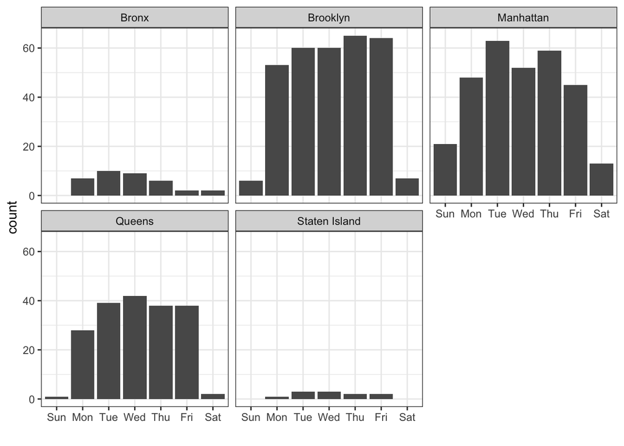

| borough | Mon | Tue | Wed | Thu | Fri | Sat | Sun |
| --- | --- | --- | --- | --- | --- | --- | --- |
| Bronx | 7 | 10 | 9 | 6 | 2 | 2 | 0 |
| Brooklyn | 53 | 60 | 60 | 65 | 64 | 7 | 6 |
| Manhattan | 48 | 63 | 52 | 59 | 45 | 13 | 21 |
| Queens | 28 | 39 | 42 | 38 | 38 | 2 | 1 |
| Staten Island | 1 | 3 | 3 | 2 | 2 | 0 | 0 |

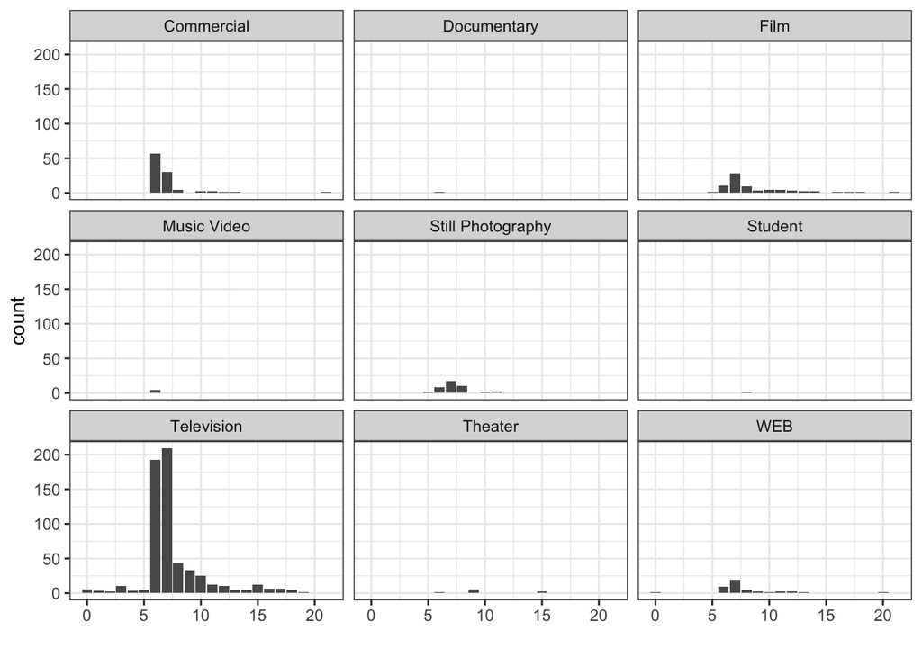

| start_hour | Commercial | Documentary | Film | Music Video | Still Photography | Student | Television | Theater | WEB |
| --- | --- | --- | --- | --- | --- | --- | --- | --- | --- |
| 0 | 0 | 0 | 0 | 0 | 0 | 0 | 5 | 0 | 1 |
| 1 | 0 | 0 | 0 | 0 | 0 | 0 | 3 | 0 | 0 |
| 2 | 0 | 0 | 0 | 0 | 0 | 0 | 2 | 0 | 0 |
| 3 | 0 | 0 | 0 | 0 | 0 | 0 | 10 | 0 | 0 |
| 4 | 0 | 0 | 0 | 0 | 0 | 0 | 3 | 0 | 0 |
| 5 | 0 | 0 | 1 | 0 | 1 | 0 | 4 | 0 | 0 |
| 6 | 57 | 1 | 10 | 4 | 8 | 0 | 192 | 1 | 9 |
| 7 | 30 | 0 | 28 | 0 | 17 | 0 | 209 | 0 | 19 |
| 8 | 4 | 0 | 9 | 0 | 10 | 1 | 43 | 0 | 4 |
| 9 | 0 | 0 | 3 | 0 | 0 | 0 | 33 | 5 | 2 |
| 10 | 2 | 0 | 4 | 0 | 1 | 0 | 25 | 0 | 1 |
| 11 | 2 | 0 | 4 | 0 | 2 | 0 | 12 | 0 | 2 |
| 12 | 1 | 0 | 3 | 0 | 0 | 0 | 10 | 0 | 2 |
| 13 | 1 | 0 | 2 | 0 | 0 | 0 | 4 | 0 | 1 |
| 14 | 0 | 0 | 2 | 0 | 0 | 0 | 4 | 0 | 0 |
| 15 | 0 | 0 | 0 | 0 | 0 | 0 | 12 | 2 | 0 |
| 16 | 0 | 0 | 1 | 0 | 0 | 0 | 6 | 0 | 0 |
| 17 | 0 | 0 | 1 | 0 | 0 | 0 | 6 | 0 | 0 |
| 18 | 0 | 0 | 1 | 0 | 0 | 0 | 4 | 0 | 0 |
| 19 | 0 | 0 | 0 | 0 | 0 | 0 | 1 | 0 | 0 |
| 20 | 0 | 0 | 0 | 0 | 0 | 0 | 0 | 0 | 1 |
| 21 | 1 | 0 | 1 | 0 | 0 | 0 | 0 | 0 | 0 |